**Code Visibility and Accessibility**

The R code chunks in this project are hidden by default. The `Code` drop down at the beginning of the project allows for all chunks to be shown at once for better readability. Alternatively, individual code sections can be shown by clicking the `Code` button above each chunk. Clicking the button again will hide the code.

```r
# Global chunk options
knitr::opts_chunk$set(
  message = FALSE,
  warning = FALSE,
  comment = NA,
  fig.pos = 'H'
)

# Libraries
library(dplyr)
library(tidyverse)
library(ggplot2)
library(plotly)
library(ggthemes)
library(knitr)
library(simmer)
library(simmer.plot)
```

# Business Context and Objective

ABC Co. operates a multi-stage manufacturing process serving international clients across four countries. While the system appears stable under average operating conditions, variability in order arrivals and processing times introduces operational risk and hidden cost exposure. In particular, delays between moulding and inspection incur a degradation cost of £150 per minute, making capacity planning a financially material decision rather than purely operational. This project applies discrete-event simulation to assess whether ABC Co.’s current resource allocation is economically optimal and to evaluate how targeted capacity investments could reduce delay-related costs. By modelling the end-to-end manufacturing flow and testing alternative machine allocation strategies, the analysis converts operational performance into financial outcomes. The aim is to support capacity decisions that minimise risk, avoid ineffective investment, and improve operational resilience.

# Conceptual Model

## Process Overview

ABC Co.’s production system consists of three consecutive stages: moulding, inspection, and packaging. Products are manufactured for clients from Chile, Morocco, Portugal, and Greece. Processing times at each stage vary by country and follow exponential distributions.

```r
# Define production parameters by country
production_parameters <- data.frame(
  Country    = c("Chile", "Morocco", "Portugal", "Greece"),
  Moulding   = c(5.3, 4.4, 4.6, 2.5),
  Inspection = c(3.7, 1.3, 5.2, 3.4),
  Packaging  = c(3.8, 3.9, 3.8, 3.1)
)

# Display the table
kable(production_parameters, caption = "Production Parameters by Country")
```

Table 1: Production Parameters by Country

| Country | Moulding | Inspection | Packaging |
| --- | --- | --- | --- |
| Chile | 5.3 | 3.7 | 3.8 |
| Morocco | 4.4 | 1.3 | 3.9 |
| Portugal | 4.6 | 5.2 | 3.8 |
| Greece | 2.5 | 3.4 | 3.1 |

Customer orders arrive at random intervals, following a normal distribution with a mean inter-arrival time of 0.6 minutes and a standard deviation of 0.1 minutes.

The facility is equipped with 10 moulding machines, 9 inspection tables, and 9 packaging machines. Products move through each stage in sequence. If a resource is busy, items wait in a queue until it becomes available. (Figure 1).

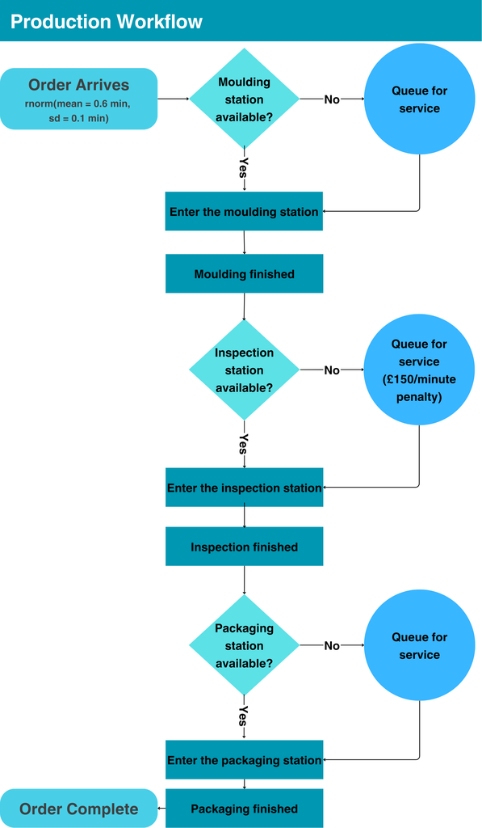

Figure 1: Workflow Diagram of the Production Process

```r
# Include an external image
knitr::include_graphics("Workflow.png")
```

## Scenario Analysis

The project explores the impact of adding six machines distributed across the moulding and packaging stages in different combinations (e.g., 1 for moulding and 5 for packaging, 2 and 4, up to 5 and 1). Each scenario ensures that both stages receive at least one additional machine. A key cost factor examined is the delay between moulding and inspection, with each minute of waiting incurring a degradation cost of £150.

## Performance Metrics

The simulation focuses on two key metrics:

- **Average waiting time** at each stage, calculated as the difference between the total time spent in the system and the processing time at that stage (waiting time = end time – start time – activity time).
- **Average degradation cost** due to delays between moulding and inspection.

## Assumptions & Simplifications

To streamline the analysis and deliver insights within the project timeframe, several assumptions and simplifications were made:

- The system operates continuously in a steady state, where long-term performance remains stable.
- The system’s performance is evaluated after an initial warm-up period to ensure stable and representative results. Ideally, each simulation run would have its warm-up period. However, due to time constraints, a single warm-up period—estimated from a one-replication run—was applied to all replications. This approach is supported by Law (2015, pp. 511–523), who notes that when the system’s stochastic behaviour is consistent across replications, a common warm-up period can be used effectively.
- Historical order data was used to reflect country-based demand proportions, which are assumed to remain constant over time. Additionally, all orders are assumed to be received and fulfilled on the same day, regardless of the actual timeline in the historical dataset.
- The waiting time between moulding and inspection is measured as the waiting time at the inspection stage.
- Machines are assumed to be always available, with no breakdowns, set-up times, or maintenance interruptions.
- Raw materials and staffing are considered unlimited, removing external supply and labour constraints.
- All queues follow a First-Come-First-Served policy, and products are processed individually—no batching is involved.
- The cost of acquiring and installing the six additional machines used in scenario analysis is not considered as part of the cost reduction strategy. This financial aspect is beyond the scope of the current study and is therefore excluded from the simulation and conclusions.

# Data Analysis

## Data Collection and Preparation

The accuracy and reliability of any discrete-event simulation (DES) depend largely on the quality and relevance of the input data. A sample of ABC Co.’s historical order records was used to analyse ordering patterns across its four customer regions: Chile, Morocco, Portugal, and Greece.

```r
# Load data
data <- read_csv("Data.csv")

# Preview the first few rows
knitr::kable(
  head(data),
  caption = "Preview of the sample of ABC Co.’s historical order records"
)
```

Table 2: Preview of the sample of ABC Co.’s historical order records

| Date | From |
| --- | --- |
| Sunday, 4 February 2018 | Portugal |
| Friday, 6 December 2019 | Portugal |
| Wednesday, 21 July 2021 | Greece |
| Tuesday, 18 September 2018 | Chile |
| Wednesday, 28 October 2020 | Portugal |
| Wednesday, 12 January 2022 | Morocco |

```r
# Show summary statistics
summary(data)
```

```
     Date               From
 Length:1000        Length:1000
 Class :character   Class :character
 Mode  :character   Mode  :character
```

To prepare the data for analysis, the order `Date` field—stored initially as a text string—was converted to a standard date format to enable time-based insights.

```r
# Load date-handling library
library(lubridate)

# Clean and format the Date column, then sort the data
data <- data |>
  mutate(Date = dmy(gsub("^[A-Za-z]+, ", "", Date))) |>
  arrange(Date)

# Generate a detailed data description
Hmisc::describe(data)
```

```
data

 2  Variables      1000  Observations
--------------------------------------------------------------------------------
Date
         n    missing   distinct       Info       Mean    pMedian        Gmd
      1000          0        770          1 2020-06-11      18424      599.8
       .05        .10        .25        .50        .75        .90        .95
2018-03-27 2018-06-20 2019-03-19 2020-06-10 2021-08-21 2022-06-12 2022-10-01

lowest : 2018-01-03 2018-01-04 2018-01-08 2018-01-09 2018-01-14
highest: 2022-12-22 2022-12-23 2022-12-25 2022-12-26 2022-12-28
--------------------------------------------------------------------------------
From
       n  missing distinct
    1000        0        4

Value         Chile   Greece  Morocco Portugal
Frequency       132      305      236      327
Proportion    0.132    0.305    0.236    0.327
--------------------------------------------------------------------------------
```

An initial exploratory analysis (Figure 2) revealed that Portugal and Greece together account for over 60% of total orders, while Chile represents just 13%.

```r
ggplotly(
  data |>
    count(From) |>
    mutate(prop = n / sum(n)) |>
    mutate(From = fct_reorder(From, prop, .desc = TRUE)) |>
    ggplot(aes(x = From, y = prop, group = 1)) +
    geom_bar(stat = "identity", fill = "steelblue") +
    labs(
      title = "Proportion of Orders per Country",
      x = "",
      y = ""
    ) +
    theme_tufte(base_family = "Helvetica") +
    theme(
      plot.title = element_text(hjust = 0.5),
      legend.position = "top",
      axis.text.x = element_text(angle = 45, hjust = 1, size = 9)
    ) +
    scale_y_continuous(labels = scales::percent) +
    scale_fill_brewer(palette = "Blues", direction = -1) +
    scale_color_manual(values = c("darkblue", "blue", "royalblue"))
) |>
  layout(
    annotations = list(
      text = "Hover over the plot for details",
      x = 0.5,
      y = 1.05,
      xref = "paper",
      yref = "paper",
      showarrow = FALSE,
      font = list(size = 12, family = "Helvetica")
    )
  )
```

[interactive chart not shown]

Figure 2: Order proportions per country.

Monthly trends (Figure 3) showed consistent order activity across time, with only occasional gaps for specific countries, confirming the dataset’s reliability for modelling purposes.

```r
ggplotly(
  data |>
    mutate(year_month = format(Date, "%Y-%m")) |>  # Extract Year-Month
    ggplot(aes(x = year_month)) +
      geom_bar(fill = "steelblue") +
      facet_wrap(~ From) +
      labs(
        title = "Orders per Country",
        x = "Year-Month",
        y = "Count of Orders"
      ) +
      theme_tufte(base_family = "Helvetica") +
      theme(
        plot.title = element_text(hjust = 0.5),
        legend.position = "top",
        axis.text.x = element_text(angle = 90, hjust = 1, size = 5)
      ) +
      scale_fill_brewer(palette = "Blues", direction = -1) +
      scale_color_manual(values = c("darkblue", "blue", "royalblue"))
) |>
  layout(
    annotations = list(
      text = "Hover over the plot for details",
      x = 0.5,
      y = 1.075,
      xref = "paper",
      yref = "paper",
      showarrow = FALSE,
      font = list(size = 12, family = "Helvetica")
    )
  )
```

[interactive chart not shown]

Figure 3: Distribution of orders per date and country.

Due to the limited scope of the historical dataset—primarily order dates and countries of origin—synthetic data was generated to support a robust simulation. This included:

- Order arrivals, modelled using a normal distribution (mean: 0.6 minutes, standard deviation: 0.1 minutes), in line with observed historical patterns.
- Processing times for each production stage, sampled from exponential distributions specific to each country.

```r
# Function to generate simulated orders with processing times
generate_orders <- function(data, production_parameters) {

  # Generate arrival times
  orders <- data |>
    mutate(ArrivalTime = rnorm(n(), mean = 0.6, sd = 0.1))

  # Merge with production parameters
  orders <- orders |>
    left_join(production_parameters, by = c("From" = "Country"))

  # Simulate processing times for each stage
  orders <- orders |>
    mutate(
      MouldingTime   = rexp(n(), rate = 1 / Moulding),
      InspectionTime = rexp(n(), rate = 1 / Inspection),
      PackagingTime  = rexp(n(), rate = 1 / Packaging)
    ) |>
    dplyr::select(-Moulding, -Inspection, -Packaging) |>
    arrange(Date)

  return(orders)
}

# Generate a sample of orders
set.seed(123)
orders_generated_sample <- generate_orders(data, production_parameters)

# Display and summarise the sample
knitr::kable(head(orders_generated_sample), caption = "Preview of the Generated Orders")
```

Table 3: Preview of the Generated Orders

| Date | From | ArrivalTime | MouldingTime | InspectionTime | PackagingTime |
| --- | --- | --- | --- | --- | --- |
| 2018-01-03 | Portugal | 0.5439524 | 7.6529565 | 5.154851 | 0.0830213 |
| 2018-01-04 | Greece | 0.5769823 | 3.8560529 | 3.418660 | 6.7997522 |
| 2018-01-04 | Portugal | 0.7558708 | 7.2667925 | 2.877702 | 3.0807833 |
| 2018-01-08 | Greece | 0.6070508 | 0.0721713 | 2.984466 | 4.9803484 |
| 2018-01-09 | Greece | 0.6129288 | 1.8293483 | 1.429767 | 2.3163499 |
| 2018-01-14 | Portugal | 0.7715065 | 24.0740333 | 4.265682 | 0.5342656 |

```r
summary(orders_generated_sample)
```

```
      Date                From            ArrivalTime      MouldingTime
 Min.   :2018-01-03   Length:1000        Min.   :0.3190   Min.   : 0.001524
 1st Qu.:2019-03-19   Class :character   1st Qu.:0.5372   1st Qu.: 1.044152
 Median :2020-06-10   Mode  :character   Median :0.6009   Median : 2.482796
 Mean   :2020-06-11                      Mean   :0.6016   Mean   : 3.987952
 3rd Qu.:2021-08-21                      3rd Qu.:0.6665   3rd Qu.: 5.441266
 Max.   :2022-12-28                      Max.   :0.9241   Max.   :25.734796
 InspectionTime      PackagingTime
 Min.   : 0.003819   Min.   : 0.003416
 1st Qu.: 0.832982   1st Qu.: 1.081277
 Median : 2.128350   Median : 2.554547
 Mean   : 3.606196   Mean   : 3.624447
 3rd Qu.: 4.608425   3rd Qu.: 4.845417
 Max.   :33.679915   Max.   :27.497896
```

To validate the generated data, visual checks (Figure 4) confirmed the stability of arrival intervals.

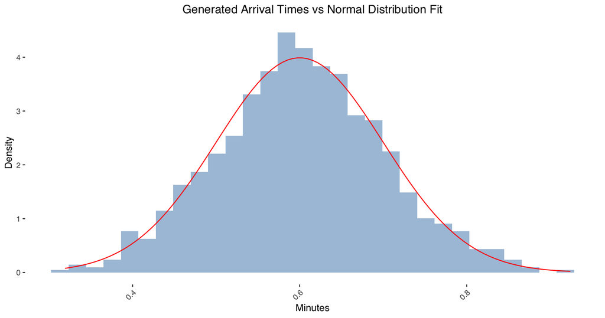

Figure 4: Normal distribution fit of generated arrival times.

```r
# Check if arrival times follow a normal distribution
ggplot(orders_generated_sample, aes(x = ArrivalTime)) +
  geom_histogram(aes(y = ..density..), bins = 30, fill = "steelblue", alpha = 0.5) +
  stat_function(
    fun = dnorm,
    args = list(mean = 0.6, sd = 0.1),
    color = "red"
  ) +
  labs(
    title = "Generated Arrival Times vs Normal Distribution Fit",
    x = "Minutes",
    y = "Density"
  ) +
  theme_tufte(base_family = "Helvetica") +
  theme(
    plot.title = element_text(hjust = 0.5),
    legend.position = "right",
    axis.text.x = element_text(angle = 45, hjust = 1)
  )
```

Furthermore, additional comparisons (Figure 5) verified generated processing times against known parameters.

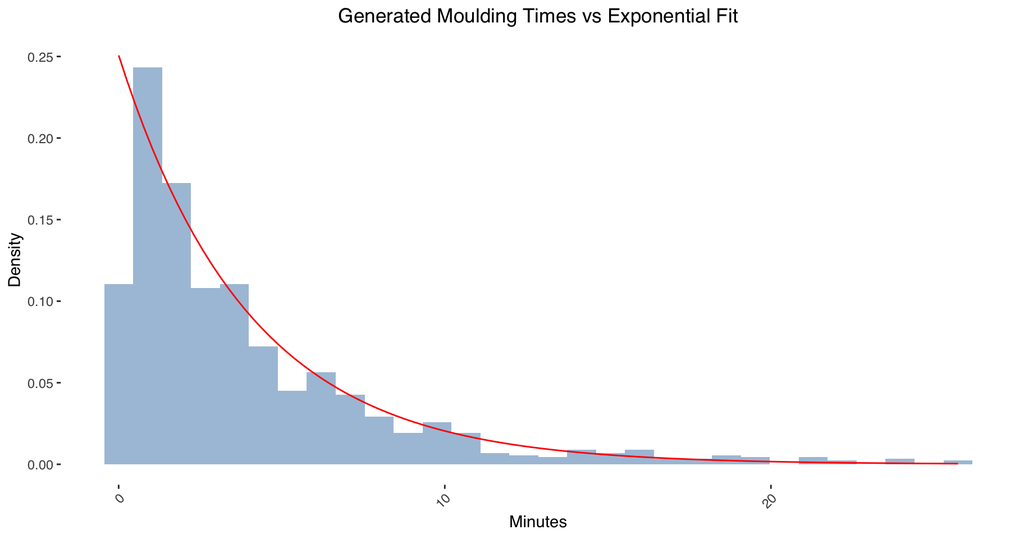

Figure 5: Exponential distribution fit of generated moulding times.

```r
# Check if moulding times follow an exponential distribution
ggplot(orders_generated_sample, aes(x = MouldingTime)) +
  geom_histogram(aes(y = ..density..), bins = 30, fill = "steelblue", alpha = 0.5) +
  stat_function(
    fun = dexp,
    args = list(rate = 1 / mean(orders_generated_sample$MouldingTime)),
    color = "red"
  ) +
  labs(
    title = "Generated Moulding Times vs Exponential Fit",
    x = "Minutes",
    y = "Density"
  ) +
  theme_tufte(base_family = "Helvetica") +
  theme(
    plot.title = element_text(hjust = 0.5),
    legend.position = "right",
    axis.text.x = element_text(angle = 45, hjust = 1)
  )
```

This modelling approach accurately reflects ABC Co.’s operational dynamics while enabling a flexible simulation environment. It supports confident scenario testing and provides a solid foundation for making informed, data-driven operational decisions.

## Simulation Model

The simulation model replicates ABC Co.’s production process using a queueing-based approach for each stage: moulding, inspection, and packaging. Each stage is modelled as an M/M/c queue, where c represents the number of servers (i.e., machines) operating at that stage. The system includes 10 moulding machines, 9 inspection tables, and 9 packaging machines in the current configuration.

Processing times—already generated using exponential distributions with country-specific parameters—are integrated into the simulation logic to reflect real-time variability in production times.

The primary goal of the simulation is to estimate average waiting times at each stage, factoring in machine availability and queuing delays.

```r
library(skimr)

moulding_machine = 10
inspection_table = 9
packaging_machine = 9

# Simulation function
simulate_plant <- function(orders, n_moulding = moulding_machine, n_inspection = inspection_table, n_packaging = packaging_machine) {

  # Create the simulation environment
  env <- simmer("ABCCo Plant")

  # Add resources
  env |>
    add_resource("Moulding", capacity = n_moulding) |>
    add_resource("Inspection", capacity = n_inspection) |>
    add_resource("Packaging", capacity = n_packaging)

  # Define the trajectory (process flow)
  traj <- trajectory("Order Process") |>
    seize("Moulding", 1) |>
    timeout_from_attribute("moulding_time") |>
    release("Moulding", 1) |>

    seize("Inspection", 1) |>
    timeout_from_attribute("inspection_time") |>
    release("Inspection", 1) |>

    seize("Packaging", 1) |>
    timeout_from_attribute("packaging_time") |>
    release("Packaging", 1)

  # Prepare arrival data with processing time attributes
  arrival_data <- orders |>
    transmute(
      time = ArrivalTime,
      moulding_time = MouldingTime,
      inspection_time = InspectionTime,
      packaging_time = PackagingTime
    )

  # Add a single generator using add_dataframe (efficient)
  env |>
    add_dataframe("order", traj, arrival_data, mon = 2) |>
    run()

  return(env)
}

# run simulation with 1 replication
set.seed(123)
orders <- generate_orders(data, production_parameters)
env <- simulate_plant(orders)
# Print results
initial_simulation_results <- get_mon_arrivals(env) |>
  arrange(start_time) |>  # Order by start_time
  mutate(waiting_time = end_time - activity_time - start_time)

# Display preview
knitr::kable(
  head(initial_simulation_results),
  caption = "Preview of the Initial Simulation (1 replication)"
)
```

Table 4: Preview of the Initial Simulation (1 replication)

| name | start_time | end_time | activity_time | finished | replication | waiting_time |
| --- | --- | --- | --- | --- | --- | --- |
| order0 | 0.5439524 | 13.43478 | 12.890828 | TRUE | 1 | 0 |
| order1 | 1.1209347 | 15.19540 | 14.074465 | TRUE | 1 | 0 |
| order2 | 1.8768055 | 15.10208 | 13.225277 | TRUE | 1 | 0 |
| order3 | 2.4838564 | 10.52084 | 8.036986 | TRUE | 1 | 0 |
| order4 | 3.0967851 | 8.67225 | 5.575465 | TRUE | 1 | 0 |
| order5 | 3.8682916 | 32.74227 | 28.873981 | TRUE | 1 | 0 |

To ensure meaningful performance insights, it is crucial to exclude the initial “start-up” phase of the simulation, where results may not yet be stable. This period, known as the warm-up period, allows the system to reach a steady state before performance metrics are recorded.

While the ideal method involves calculating a unique warm-up period for each simulation run, a single warm-up value was used for all runs to streamline analysis. This value was determined using the marginal standard error rule (MSER), applied to a baseline simulation with one replication. This approach is accepted by Law (2015, pp. 511–523) when the system’s stochastic behaviour is consistent across runs, offering a practical balance between accuracy and efficiency.

As shown in Figure 6, the system stabilises after the first 280 orders. Based on the MSER heuristic, these initial orders are excluded from the performance analysis to avoid skewed results.

```r
# Compute MSER for each truncation point
compute_mser <- function(data) {
  n <- length(data)
  mser_values <- numeric(n / 2)

  for (i in 1:(n / 2)) {
    truncated <- data[i:n]
    mser_values[i] <- sd(truncated) / mean(truncated)
  }

  return(mser_values)
}

# Apply MSER heuristic to waiting times
mser_values <- compute_mser(initial_simulation_results$waiting_time)
warmup_mser <- which.min(mser_values)

# Prepare data for plotting
mser_df <- data.frame(
  Order = 1:length(mser_values),
  MSER  = mser_values
)

# Plot MSER values with warm-up indicator
ggplotly(
  ggplot(mser_df, aes(x = Order, y = MSER)) +
    geom_line(colour = "steelblue", alpha = 0.5) +
    geom_vline(xintercept = warmup_mser, colour = "steelblue", linetype = "dashed") +
    annotate(
      "text",
      x = warmup_mser,
      y = max(mser_values),
      label = paste("Warm-up at Order", warmup_mser),
      colour = "steelblue",
      hjust = -5.5
    ) +
    labs(
      title = "MSER Heuristic for Warm-up Period",
      x = "Order",
      y = "MSER Value"
    ) +
    theme_tufte(base_family = "Helvetica") +
    theme(
      plot.title = element_text(hjust = 0.5),
      legend.position = "top",
      axis.text.x = element_text(angle = 45, hjust = 1)
    )
)|>
  layout(
    annotations = list(
      text = "Hover over the plot for details",
      x = 0.5,
      y = 1.05,
      xref = "paper",
      yref = "paper",
      showarrow = FALSE,
      font = list(size = 12, family = "Helvetica")
    )
  )
```

[interactive chart not shown]

Figure 6: Identifying warm-up orders using MSER heuristic.

Due to the randomness in both order arrivals and processing times, multiple independent replications are required to obtain statistically reliable results. To determine an appropriate number of replications, cumulative mean waiting times were analysed to assess when performance metrics stabilised.

```r
# ---- Parameters ----
set.seed(42)                # For reproducibility
z <- 1.96                   # 95% confidence
w <- 0.2                    # Desired half-width of CI
min_reps <- 100              # Minimum replications before estimating
results <- c()              # To store results
max_reps <- 500             # Safety stop

# ---- Loop to determine required replications ----
repeat {
  orders <- generate_orders(data, production_parameters)

  # Simulate environment
  env <- simulate_plant(orders)

  # Get arrivals and calculate waiting time per order (post-warmup)
  arrivals <- get_mon_arrivals(env, per_resource = TRUE) |>
    mutate(
    waiting_time = round(end_time - activity_time - start_time, 2),
    order_id = parse_number(name)) |>
  group_by(replication) |>
  arrange(start_time, .by_group = TRUE) |>
  filter(order_id > warmup_mser) |>
  ungroup()

  # Calculate mean waiting time (only if arrivals exist)
  if (nrow(arrivals) == 0) {
    result <- NA
  } else {
    result <- mean(arrivals$waiting_time, na.rm = TRUE)
  }

  # Store result
  results <- c(results, result)

  # Check if enough clean results to estimate required replications
  if (length(results) >= min_reps) {
    s <- sd(results)
    mean_val <- mean(results)
    n_needed <- ceiling((z * s / w)^2)

    if (length(results) >= n_needed || length(results) >= max_reps) {
      break
    }
  }
}

# ---- Final Output ----
cat(paste(
  " Final replications used:", length(results), "\n",
  "Mean waiting time:", round(mean(results), 3), "\n",
  "95% CI Half-width:", round((z * sd(results)) / sqrt(length(results)), 3), "\n"
))
```

```
 Final replications used: 100
 Mean waiting time: 0.096
 95% CI Half-width: 0.007
```

Figure 7 shows that cumulative mean waiting times stabilised after approximately 50 replications, indicating that further replications would have minimal impact on result accuracy.

```r
# Build cumulative statistics over replications
ci_data <- data.frame(
  Replication = seq_along(results),
  MeanWaitingTime = results
) |>
  mutate(
    CumulativeMean = cummean(MeanWaitingTime),
    SD = sapply(1:n(), function(i) if (i > 1) sd(MeanWaitingTime[1:i]) else 0),
    CI_HalfWidth = 1.96 * SD / sqrt(Replication),
    LowerCI = CumulativeMean - CI_HalfWidth,
    UpperCI = CumulativeMean + CI_HalfWidth
  )

# Plot convergence of average waiting time
ggplotly(
  ggplot(ci_data, aes(x = Replication)) +
    geom_line(aes(y = CumulativeMean), color = "steelblue", size = 0.7) +
    geom_ribbon(aes(ymin = LowerCI, ymax = UpperCI), alpha = 0.2, fill = "steelblue") +
    geom_vline(xintercept = 50, colour = "steelblue", linetype = "dashed") +
    labs(
      title = "Convergence of Average Waiting Time Across Replications",
      x = "Number of Replications",
      y = "Cumulative Average Waiting Time",
      caption = "Shaded area = 95% Confidence Interval"
    ) +
    theme_tufte(base_family = "Helvetica") +
    theme(
      plot.title = element_text(hjust = 0.5),
      legend.position = "right",
      axis.text.x = element_text(angle = 45, hjust = 1)
    )
) |>
  layout(
    annotations = list(
      text = "Hover over the plot for details",
      x = 0.5,
      y = 1.05,
      xref = "paper",
      yref = "paper",
      showarrow = FALSE,
      font = list(size = 12, family = "Helvetica")
    )
  )
```

[interactive chart not shown]

Figure 7: Cumulative average waiting time across replications.

To ensure robustness, the simulation performed 50 independent replications, providing sufficient statistical confidence in the reported performance measures.

```r
# Run multiple replications and track arrivals
set.seed(42)
n_reps <- 50

rep_arrivals <- lapply(1:n_reps, function(i) {
  orders <- generate_orders(data, production_parameters)
  env <- simulate_plant(orders)

  get_mon_arrivals(env, per_resource = TRUE) |>
    mutate(replication = i) |>
    mutate(
      waiting_time = round(end_time - activity_time - start_time, 2),
      order_id = parse_number(name)
    ) |>
    group_by(replication) |>
    arrange(start_time, .by_group = TRUE) |>
    filter(order_id > warmup_mser) |>
    ungroup()
})

# Combine results from all replications
all_arrivals <- bind_rows(rep_arrivals)

# Summary output
cat("Replications tracked:", length(unique(all_arrivals$replication)), "\n")
```

```
Replications tracked: 50
```

```r
# Preview of simulation results
knitr::kable(
  head(all_arrivals),
  caption = "Preview of the Simulation Results (50 replications, excluding warm-up orders"
)
```

Table 5: Preview of the Simulation Results (50 replications, excluding warm-up orders

| name | start_time | end_time | activity_time | resource | replication | waiting_time | order_id |
| --- | --- | --- | --- | --- | --- | --- | --- |
| order281 | 168.5482 | 169.0158 | 0.4676739 | Moulding | 1 | 0.00 | 281 |
| order281 | 169.0158 | 169.8127 | 0.7968853 | Inspection | 1 | 0.00 | 281 |
| order282 | 169.0912 | 169.7658 | 0.6746243 | Moulding | 1 | 0.00 | 282 |
| order283 | 169.7548 | 178.5807 | 8.8259342 | Moulding | 1 | 0.00 | 283 |
| order282 | 169.7658 | 172.0101 | 2.2442206 | Inspection | 1 | 0.00 | 282 |
| order281 | 169.8127 | 173.6532 | 2.0248702 | Packaging | 1 | 1.82 | 281 |

## Verification & Validation

Verification ensures the simulation model was developed and implemented correctly, according to the intended design and logic. The model was built using the `simmer` package in R and carefully reviewed to confirm that it accurately reflects ABC Co.’s real-world manufacturing process—moving through the three stages of moulding, inspection, and packaging.

Each stage was programmed as an M/M/c queue, ensuring that:

- Resources are correctly seized before processing begins,
- Processing times follow the specified country-based exponential distributions,
- Resources are released in the proper sequence after completion.

A sample of simulated orders was manually traced through the system to verify the correct model behaviour. This confirmed that:

- Order arrivals matched the intended normal distribution,
- Stage durations reflected the country-specific exponential patterns,
- The flow of products between stages was uninterrupted and logically consistent.

In addition, key performance indicators—such as waiting times, queue lengths, and machine utilisation—were tested under both normal and extreme load conditions to ensure the system responded in a stable and predictable manner.

Validation evaluates whether the model accurately represents the real-world system or provides a sound approximation based on theoretical expectations. In the absence of detailed operational data for ABC Co., validation was carried out using a combination of statistical checks and theoretical comparisons.

First, the warm-up period was validated by confirming that the first 280 orders were excluded from each simulation run (Figure 8, ensuring performance metrics were only calculated once the system had reached a stable state.

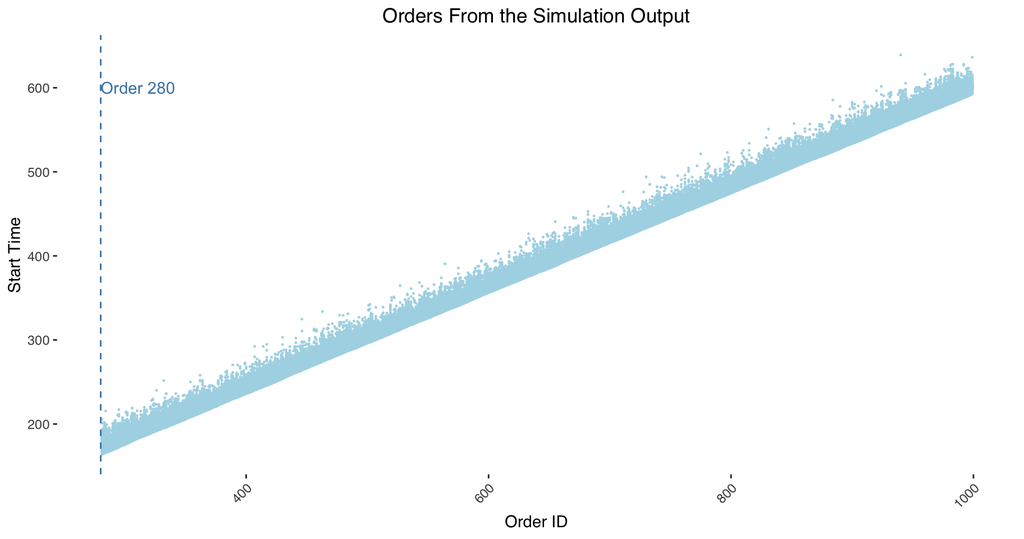

Figure 8: Orders considered in the simulation output.

```r
# Plot start time by order ID with warm-up cutoff indicator
ggplot(all_arrivals, aes(x = order_id, y = start_time)) +
  geom_point(color = "lightblue", size=0.2) +
  geom_vline(xintercept = warmup_mser, color = "steelblue", linetype = "dashed") +
  annotate(
    "text",
    x = warmup_mser,
    y = 600,
    label = paste("Order", warmup_mser),
    colour = "steelblue",
    hjust = 0
  ) +
  labs(
    title = "Orders From the Simulation Output",
    x = "Order ID",
    y = "Start Time"
  ) +
  theme_tufte(base_family = "Helvetica") +
  theme(
    plot.title = element_text(hjust = 0.5),
    legend.position = "right",
    axis.text.x = element_text(angle = 45, hjust = 1)
  )
```

Having the correct implementation of input parameters, it was then verified that the simulated activity times closely followed their intended exponential distributions (Figure 9).

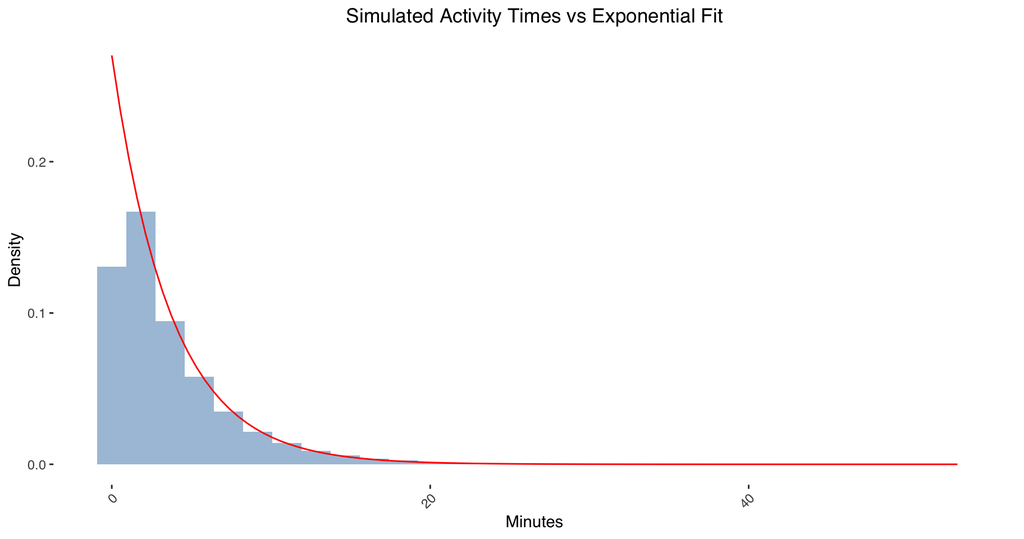

Figure 9: Exponential fit of simulated activity times.

```r
# Check if activity times follow an exponential distribution
ggplot(all_arrivals, aes(x = activity_time)) +
  geom_histogram(aes(y = ..density..), bins = 30, fill = "steelblue", alpha = 0.5) +
  stat_function(
    fun = dexp,
    args = list(rate = 1 / mean(all_arrivals$activity_time)),
    color = "red"
  ) +
  labs(
    title = "Simulated Activity Times vs Exponential Fit",
    x = "Minutes",
    y = "Density"
  ) +
  theme_tufte(base_family = "Helvetica") +
  theme(
    plot.title = element_text(hjust = 0.5),
    legend.position = "right",
    axis.text.x = element_text(angle = 45, hjust = 1)
  )
```

To validate the model’s output, simulated performance metrics, such as average waiting times at the inspection stage, were compared with theoretical values derived from standard M/M/c queuing models.

```r
# Load queueing analysis library
library(queueing)

# Summarise simulation results by stage
summary_table <- all_arrivals |>
  group_by(resource) |>
  summarize(
    "Avg Waiting"  = round(mean(waiting_time), 2),
    "Max Waiting"  = round(max(waiting_time), 2),
    "Total Orders" = n(),
    .groups = "drop"
  )

# Define parameters
Mean_IAT        <- 0.6  # Mean inter-arrival time
Mean_Inspection <- mean(production_parameters$Inspection)  # Mean service time for Inspection

# Theoretical queueing model for Inspection stage (multi-server)
i_mm1 <- NewInput.MMC(lambda = 1 / Mean_IAT, mu = 1 / Mean_Inspection, c = inspection_table)
model <- QueueingModel(i_mm1)

# Compare simulated and theoretical waiting times
cat(paste(
  " Simulated Mean Waiting Time in Inspection:", summary_table$`Avg Waiting`[1], "minutes\n",
  "Theoretical Mean Waiting Time in Inspection Queue (Wq):", round(model$Wq, 2), "minutes\n"
))
```

```
 Simulated Mean Waiting Time in Inspection: 0.1 minutes
 Theoretical Mean Waiting Time in Inspection Queue (Wq): 0.15 minutes
```

The simulated average waiting time (0.1 minutes) was close to the theoretical expectation (0.15 minutes), with minor differences attributed to the variability introduced by the mix of country-specific parameters. This confirms the model realistically captures queuing behaviour.

Finally, Figure 10 shows that the distribution of simulated processing times closely matches the expected exponential shape, with a slightly heavier tail. This variation is anticipated due to the combination of different exponential distributions across countries, and it reflects the complexity of real-world operations.

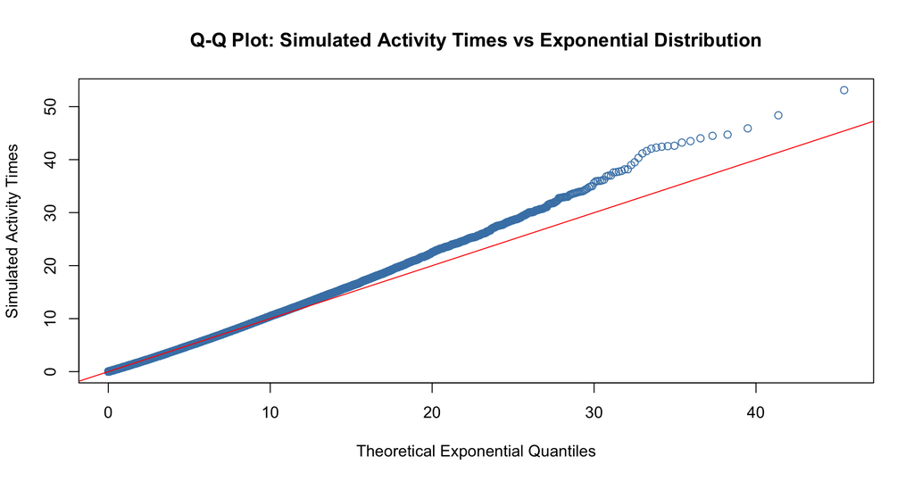

Figure 10: Q-Q plot comparing simulated activity times to a theoretical exponential distribution.

```r
# Simulated activity times from the simulation
simulated_activity_times <- all_arrivals$activity_time

# Theoretical exponential quantiles
theoretical_quantiles <- qexp(
  ppoints(length(simulated_activity_times)),
  rate = 1 / mean(simulated_activity_times)
)

# Q-Q plot to assess exponential fit
qqplot(
  theoretical_quantiles,
  sort(simulated_activity_times),
  main = "Q-Q Plot: Simulated Activity Times vs Exponential Distribution",
  xlab = "Theoretical Exponential Quantiles",
  ylab = "Simulated Activity Times",
  col = "steelblue"
)
abline(0, 1, col = "red", lwd = 1)  # Reference line
```

Together, these verification and validation steps confirm that the simulation model is both technically sound and a reliable tool for analysing ABC Co.’s manufacturing system under different resource configurations.

# Key Insights and Business Impact

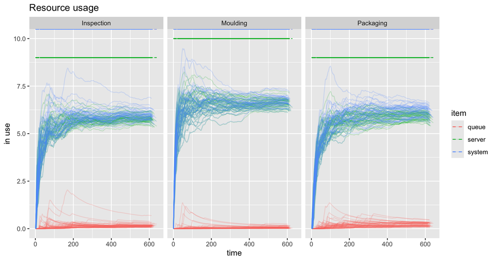

```r
# Track resource usage across multiple replications
set.seed(42)

rep_resources <- lapply(1:n_reps, function(i) {
  orders <- generate_orders(data, production_parameters)
  env <- simulate_plant(orders)

  get_mon_resources(env) |>
    mutate(replication = i)
})

# Combine results from all replications
all_resources <- bind_rows(rep_resources)

# Plot resource usage
plot(all_resources)
```

Waiting times across stages remained relatively low (Figure 12). Moulding had the shortest average wait (0.04 minutes), followed by inspection (0.10 minutes), while packaging had the highest (0.15 minutes).

```r
# Interactive bar chart of average waiting times per stage
ggplotly(
  summary_table |>
    dplyr::select(resource, `Avg Waiting`) |>
    mutate(resource = factor(resource, levels = c("Moulding", "Inspection", "Packaging"))) |>
    ggplot(aes(x = resource, y = `Avg Waiting`)) +
      geom_col(fill = "steelblue") +
      labs(
        title = "Average Waiting Time per Stage",
        x = "",
        y = "Minutes"
      ) +
      theme_tufte(base_family = "Helvetica") +
      theme(
        plot.title = element_text(hjust = 0.5),
        legend.position = "none",
        axis.text.x = element_text(angle = 45, hjust = 1, size = 9)
      )
) |>
  layout(
    annotations = list(
      text = "Hover over the plot for details",
      x = 0.5,
      y = 1.05,
      xref = "paper",
      yref = "paper",
      showarrow = FALSE,
      font = list(size = 12, family = "Helvetica")
    )
  )
```

[interactive chart not shown]

Figure 12: Average waiting time per stage (50 replications, excluding warm-up orders).

While most orders were processed with minimal delay, occasional spikes in waiting times were observed, especially in inspection and packaging (Figure 13), where delays occasionally exceeded 5 minutes.

```r
# Interactive histogram of waiting times by stage
ggplotly(
  all_arrivals |>
    mutate(resource = factor(resource, levels = c("Moulding", "Inspection", "Packaging"))) |>
    ggplot(aes(x = waiting_time)) +
      geom_histogram(binwidth = 1, fill = "steelblue", color = "white") +
      facet_wrap(~resource, scales = "free_y") +
      labs(
        title = "Distribution of Waiting Times per Stage",
        x = "Minutes",
        y = "Frequency"
      ) +
      theme_tufte(base_family = "Helvetica") +
      theme(
        plot.title = element_text(hjust = 0.5),
        legend.position = "right",
        axis.text.x = element_text(angle = 45, hjust = 1)
      )
)
```

[interactive chart not shown]

Figure 13: Distribution of waiting times per stage (50 replications, excluding warm-up orders).

From a business perspective, the most important finding is that although infrequent, inspection delays are disproportionately costly because of the £150-per-minute degradation penalty. As a result, average performance metrics alone are insufficient for decision-making. Financial exposure is driven by peak congestion events rather than day-to-day throughput.

The analysis also shows that packaging capacity, rather than moulding capacity, is the primary driver of downstream delays and degradation costs. Increasing moulding capacity in isolation does not reduce financial losses unless packaging capacity is also strengthened. This system-wide interaction is not immediately apparent from operational metrics alone and has direct implications for capital allocation.

# Scenario Analysis: What Actually Improves Performance

Five alternative capacity-expansion scenarios were evaluated by adding six machines across the moulding and packaging stages, in various combinations. For each scenario, the average degradation cost was calculated by multiplying waiting time at inspection by the £150/minute penalty.

```r
degradation_cost_per_minute = 150

degradation_data <- all_arrivals |>
  filter(resource=="Inspection" & waiting_time > 0) |>
  dplyr::select(order_id, replication, resource, waiting_time) |>
  mutate(degradation_cost = waiting_time * degradation_cost_per_minute)

cat(paste("Average degradation cost with the default set-up of 10 moulding and 9 packaging machines: £", round(mean(degradation_data$degradation_cost),2)))
```

```
Average degradation cost with the default set-up of 10 moulding and 9 packaging machines: £ 125.77
```

Each configuration was tested using 50 independent simulation runs, with the first 280 orders excluded from analysis in each run to ensure the system had reached a steady state.

```r
start_time <- Sys.time()

# Set seed for reproducibility
set.seed(42)

# Function to simulate experiments across different machine configurations
simulate_experiments <- function(orders, machine_combinations, n_replications = n_reps) {
  results <- list()

  for (combo in machine_combinations) {
    replication_costs <- numeric(n_replications)

    for (rep in 1:n_replications) {
      # Create simulation environment with adjusted resource capacities
      env <- simmer("ABCCo Plant") |>
        add_resource("Moulding", capacity = moulding_machine + combo[1]) |>
        add_resource("Inspection", capacity = inspection_table) |>
        add_resource("Packaging", capacity = packaging_machine + combo[2])

      # Define process trajectory
      traj <- trajectory("Order Process") |>
        seize("Moulding", 1) |>
        timeout_from_attribute("moulding_time") |>
        release("Moulding", 1) |>
        seize("Inspection", 1) |>
        timeout_from_attribute("inspection_time") |>
        release("Inspection", 1) |>
        seize("Packaging", 1) |>
        timeout_from_attribute("packaging_time") |>
        release("Packaging", 1)

      # Generate order data
      orders <- generate_orders(data, production_parameters)
      arrival_data <- orders |>
        transmute(
          time = ArrivalTime,
          moulding_time = MouldingTime,
          inspection_time = InspectionTime,
          packaging_time = PackagingTime
        )

      # Run simulation
      env |>
        add_dataframe("order", traj, arrival_data, mon = 2) |>
        run()

      # Extract arrivals and compute cost
      arrivals <- get_mon_arrivals(env, per_resource = TRUE) |>
        mutate(
          waiting_time = round(end_time - activity_time - start_time, 2),
          order_id = parse_number(name)
        ) |>
        arrange(start_time, .by_group = TRUE) |>
        filter(order_id > warmup_mser) |>
        filter(resource == "Inspection" & waiting_time > 0)

      replication_costs[rep] <- mean(arrivals$waiting_time, na.rm = TRUE) * degradation_cost_per_minute
    }

    # Store average cost for each configuration
    results[[paste(combo[1], combo[2], sep = ",")]] <- tibble(
      moulding_machines   = moulding_machine + combo[1],
      packaging_machines  = packaging_machine + combo[2],
      cost                = mean(replication_costs, na.rm = TRUE)
    )
  }

  return(bind_rows(results))
}

# Define machine configurations to test
machine_combinations <- list(
  c(1, 5), c(2, 4), c(3, 3), c(4, 2), c(5, 1)
)

# Run experiments
experiment_results <- simulate_experiments(orders, machine_combinations, n_replications = n_reps)

end_time <- Sys.time()
execution_time <- round(difftime(end_time, start_time, units = "secs"), 2)

cat(paste("Simulation completed in", execution_time, "seconds."))
```

```
Simulation completed in 4.47 seconds.
```

Despite identical total investment levels, only one configuration delivered a measurable financial benefit. The addition of one moulding machine and five packaging machines reduced average degradation costs from £125.77 to £120.29 per run, making it the only scenario that outperformed the current system (Figure 14). All other configurations failed to reduce costs and, in some cases, increased them, demonstrating that poorly targeted investment can worsen performance even when total capacity increases.

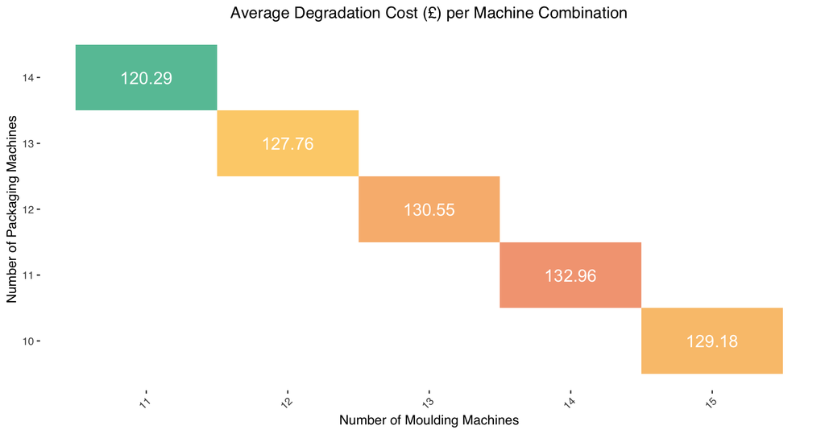

Figure 14: Average degradation costs across machine combinations.

```r
# Load color palette library
library("RColorBrewer")

# Heatmap of average degradation cost by machine combination
ggplot(experiment_results, aes(x = moulding_machines, y = packaging_machines, fill = cost)) +
  geom_tile() +
  geom_text(aes(label = round(cost, 2)), color = "white", size = 5) +
  scale_fill_gradientn(colors = c("#66C2A5", "#FED976", "#F4A582")) +
  labs(
    title = "Average Degradation Cost (£) per Machine Combination",
    x = "Number of Moulding Machines",
    y = "Number of Packaging Machines",
    fill = "Average Cost (£)"
  ) +
  theme_tufte(base_family = "Helvetica") +
  theme(
    plot.title = element_text(hjust = 0.5),
    legend.position = "none",
    axis.text.x = element_text(angle = 45, hjust = 1)
  )
```

The key takeaway is that capacity expansion decisions must be guided by system-wide behaviour rather than local intuition. Simply adding machines does not guarantee improvement. Where capacity is added matters more than how much is added.

# Conclusions

The analysis confirms that ABC Co.’s manufacturing system is operationally efficient under normal demand but financially sensitive to variability at specific stages. Packaging acts as a latent bottleneck that amplifies inspection delays, during which degradation costs are incurred. Although these delays are infrequent, their financial impact is material.

Scenario analysis shows that capacity investment must be precisely targeted to generate value. Of the options tested, only adding one moulding machine and five packaging machines reduced degradation costs. Increasing resources without regard to system interactions does not guarantee better outcomes.

Overall, this project demonstrates how discrete-event simulation can serve as a practical decision-support tool to translate operational complexity into clear, financially grounded recommendations. The approach reduces investment risk and supports more confident, cost-effective capacity planning.

# Recomendations

ABC Co. should prioritise packaging capacity when planning future equipment investments, as this stage has the greatest influence on inspection delays and degradation costs. If six additional machines are to be installed, the configuration of one moulding machine and five packaging machines should be adopted, as it is the only option shown to deliver measurable cost savings.

Inspection should remain closely monitored despite its low average waiting time, as even short delays can cause significant financial losses. Implementing early-warning indicators or real-time queue monitoring would help mitigate the risk of degradation.

Finally, the validated simulation model should be retained as a living decision-support asset. Incorporating richer operational data, such as machine downtime, maintenance schedules, and labour constraints, would further enhance its value and support ongoing operational improvement and future capacity decisions.

# References

Law, A. (2015). *Simulation Modeling and Analysis.* Fifth edition. New York: McGraw-Hill Education. Available at: https://industri.fatek.unpatti.ac.id/wp-content/uploads/2019/03/108-Simulation-Modeling-and-Analysis-Averill-M.-Law-Edisi-5-2014.pdf (Accessed: 28 March 2025)